# Predicting Alpha Signal using Microblogging Data

##### Alpha Signal is used to make purchase decision on stocks. This is currently predicted using seven stock factors. To predict Alpha more accurately, data is gathered from a microblogging site: 'Stocktwits'. Brokers and stockers tweet about the company in this microblogging site and tag the company with 'tickers', that start with a dollar sign

##### Our goal is to do find out the sentiment of these tweets and generate a sentiment score. This sentiment score will be used as an additional factor in prediction of Alpha with the previous 7 factors. The assumption being that the inclusion of sentiment score will give a better understanding of the company at the ground level and will help the investors to decide whether to invest in that particular stock or not.

### What is Alpha Signal?

##### Alpha is a metric used to gauge the outperformance of a trading portfolio over a normalised portfolio. It is one of modern portfolio theory’s statistical measures used to quantify the returns made from an investment against a benchmark. In general, a better value of alpha means the better an investment performed against market indices.

##### A single integer value represents the metric. A positive alpha value indicates that the fund performed better than benchmarks, while a negative value denotes the opposite. So an alpha of 1 tells you that investment is doing 1% better than the benchmark value. An alpha of -2 on the other hands shows you’ve underperformed against the benchmark by 2%.

### How will Sentiment Analysis play a role in predecting Alpha Signal

##### Given its importance, investment managers are constantly on the lookout for means to generate alpha for the funds they handle. Hence they are always on the lookout for any data that would influence or better that alpha value. A major factor would be sentiment data to indicate if a particular stock, currency, or market is going to move in a certain direction. Having alpha signals and sentiment data can facilitate a massive and seemingly “unfair” advantage over their competitors.

### Import all necessary python packages

```python
import numpy as np
import pandas as pd
import json
import re
import nltk
import string
import emoji
import wordcloud
import unidecode
import textblob
import keras
import collections
import datetime
import matplotlib.pyplot as plt
import pandas_profiling as pp
import imblearn
import sklearn.metrics as metrics
from sklearn import tree
import seaborn as sns
from textblob import TextBlob
from wordcloud import WordCloud
from datetime import datetime
from nltk.corpus import stopwords
from collections import Counter
from imblearn.over_sampling import SMOTE
from nltk.stem import WordNetLemmatizer
from nltk.tokenize import sent_tokenize
from nltk.tokenize import word_tokenize
from nltk.probability import FreqDist
from spacy.lang.en.stop_words import STOP_WORDS
from sklearn.naive_bayes import MultinomialNB
from sklearn.naive_bayes import ComplementNB
from sklearn.tree import DecisionTreeClassifier
from xgboost import  XGBClassifier
from sklearn.metrics import classification_report
from sklearn.feature_extraction.stop_words import ENGLISH_STOP_WORDS
from sklearn.feature_extraction.text import CountVectorizer,TfidfVectorizer
from sklearn.neural_network import MLPClassifier
from sklearn.metrics import f1_score,recall_score
from sklearn.model_selection import train_test_split
from sklearn.model_selection import RandomizedSearchCV,GridSearchCV,cross_val_score
from sklearn.model_selection import learning_curve
from keras.preprocessing.text import one_hot
from keras.preprocessing.sequence import pad_sequences
from keras.models import Sequential
from keras.layers.core import Activation, Dropout, Dense
from keras.layers import Flatten
from keras.layers import GlobalMaxPooling1D
from keras.layers.embeddings import Embedding
from keras.preprocessing.text import Tokenizer
```

### Custom Functions to read JSON and CSV data

```python
"""
This function takes in path of the file as an argument and returns the json data
"""

def readJsonFromFile(pathOfFile):
    with open (pathOfFile) as f:
        json_data = json.load(f)
    return json_data
```

```python
"""
This function takes in path of the file as an argument and returns dataframe
"""

def readCsvFromFile(pathOfFile):
    csv_data = pd.read_csv(pathOfFile)
    return csv_data
```

```python
"""
This function takes in data and returns Dataframe
"""

def convertToDf(Data):
    return pd.DataFrame(Data)
```

### Path of JSON and CSV Files

```python
PATH_OF_TRAIN_JSON_FILE = 'PhD/train_data.json'
PATH_OF_TEST_JSON_FILE = 'PhD/test_data.json'
PATH_OF_TRAIN_CSV_FILE = 'PhD/train_factors.csv'
PATH_OF_TEST_CSV_FILE = 'PhD/test_factors.csv'
```

### Reading Data and converting it into Dataframes

```python
json_train_data = readJsonFromFile(PATH_OF_TRAIN_JSON_FILE)
json_test_data = readJsonFromFile(PATH_OF_TEST_JSON_FILE)
```

```python
json_train_data = json_train_data['records']
json_test_data = json_test_data['records']
```

```python
df_json_train = convertToDf(json_train_data)
df_json_test = convertToDf(json_test_data)
```

```python
csv_train = readCsvFromFile(PATH_OF_TRAIN_CSV_FILE)
csv_test = readCsvFromFile(PATH_OF_TEST_CSV_FILE)
```

### Describing the Dataframe and getting to know the Data

### JSON Train Data

```python
df_json_train.head(15)
```

|  | sentiment_score | stocktwit_tweet | ticker | timestamp |
| --- | --- | --- | --- | --- |
| 0 | 3 | $AMD going up but hesitating however chart is ... | $AMD | 2018-09-19 18:38:28+00:00 |
| 1 | 3 | @inforlong @MariaGascon Despite\nChina trade w... | $CAT | 2018-10-09 03:51:06+00:00 |
| 2 | 2 | $AVGO WTF? | $AVGO | 2018-07-12 13:35:32+00:00 |
| 3 | 2 | $PH\n New Insider Filing On: \n MULLER KLAUS P... | $PH | 2018-07-19 03:32:50+00:00 |
| 4 | 3 | $FB if it bounces tommorrow do the right thing... | $FB | 2018-08-23 19:07:54+00:00 |
| 5 | 0 | $FB as usual......RED \nevery day. | $FB | 2018-08-02 11:40:49+00:00 |
| 6 | 2 | $AET UnitedHealth Group Goes Ex-Dividend Today... | $AET | 2018-09-07 15:01:06+00:00 |
| 7 | 4 | $NOC let&#39;s see when we can hit 310 | $NOC | 2018-09-12 20:48:40+00:00 |
| 8 | 2 | @InCyD3R @Ferrabi I bet you’re also the one sa... | $AMZN | 2018-10-28 01:19:27+00:00 |
| 9 | 2 | $AMD Pastor the Stooge | $AMD | 2018-08-17 13:35:00+00:00 |
| 10 | 2 | $NFLX called it Friday hahahaha suckers sold F... | $NFLX | 2018-08-27 12:51:21+00:00 |
| 11 | 2 | $gww EXP:7/20/2018\|MaxPain:292.5\|HighPutOI:250... | $gww | 2018-07-17 14:05:07+00:00 |
| 12 | 2 | $NFLX Day in, Day out this puppy is making peo... | $NFLX | 2018-10-18 15:36:57+00:00 |
| 13 | 2 | $AAPL | $AAPL | 2018-10-06 21:38:04+00:00 |
| 14 | 2 | $ANTM | $ANTM | 2018-08-08 13:34:42+00:00 |

```python
df_json_train.shape
```

```
(1039131, 4)
```

```python
df_json_train.ticker.value_counts().head(10)
```

```
$AMD     163675
$MU       82680
$AMZN     68155
$FB       65148
$AAPL     49561
$NFLX     45403
$NVDA     20532
$GE       19772
$MSFT     15531
$NKE      14785
Name: ticker, dtype: int64
```

```python
df_json_train.sentiment_score.value_counts()
```

```
2    464402
3    208031
4    153905
1    120771
0     92022
Name: sentiment_score, dtype: int64
```

### CSV Train Data

```python
csv_train.head(15)
```

|  | Id | date | ticker | SF1 | SF2 | SF3 | SF4 | SF5 | SF6 | SF7 | alpha |
| --- | --- | --- | --- | --- | --- | --- | --- | --- | --- | --- | --- |
| 0 | 1 | 21/08/18 | $NTAP | -0.628652 | 0.988891 | -0.055714 | 0.774379 | 0.551089 | -1.329229 | -0.995539 | 2 |
| 1 | 2 | 11/10/18 | $WYNN | 1.315786 | 1.438754 | 0.187327 | 0.608933 | -1.153030 | 1.859441 | 0.730995 | 3 |
| 2 | 3 | 21/08/18 | $DRI | -1.141388 | -1.455016 | 0.332755 | 0.674502 | 0.111326 | -0.478597 | -1.488157 | 1 |
| 3 | 4 | 10/07/18 | $ge | -0.054839 | -1.454149 | -0.162267 | -0.681870 | 0.307869 | -0.529987 | 0.404172 | 2 |
| 4 | 5 | 12/09/18 | $FE | -0.686366 | 0.838865 | 0.073830 | 0.679024 | 0.329463 | 1.262782 | -1.024042 | 2 |
| 5 | 6 | 16/09/18 | $F | 1.371319 | 0.288456 | -1.510710 | 1.887273 | 2.193964 | -1.266998 | 0.476990 | 1 |
| 6 | 7 | 25/09/18 | $LOW | 1.459736 | 0.268391 | -1.027821 | 0.229159 | 1.096598 | 1.363255 | 1.414198 | 1 |
| 7 | 8 | 27/07/18 | $ILMN | 0.381670 | 0.664366 | -0.333336 | -1.471580 | 0.317609 | 1.285183 | 1.303229 | 3 |
| 8 | 9 | 24/08/18 | $cmg | -1.189986 | 1.669897 | -0.561872 | 1.172239 | 1.912741 | -1.530536 | -1.584684 | 4 |
| 9 | 10 | 15/08/18 | $NEE | 0.166027 | -0.308584 | 0.210583 | -0.151859 | -0.523260 | -0.045953 | 0.178128 | 3 |
| 10 | 11 | 16/09/18 | $LEN | 0.487447 | 0.026027 | -0.104170 | -0.163339 | -0.113618 | 0.648811 | 0.550631 | 2 |
| 11 | 12 | 31/07/18 | $FTR | -0.144296 | -0.445019 | -0.662025 | 0.290563 | 1.396273 | 1.119907 | -0.119291 | 4 |
| 12 | 13 | 28/08/18 | $tif | -0.522953 | -0.604785 | 0.203266 | 1.000818 | -0.005014 | -1.126428 | -1.109366 | 2 |
| 13 | 14 | 11/07/18 | $COST | -0.217055 | -0.270220 | 0.019480 | -0.313066 | 0.079055 | -1.511011 | -0.007147 | 2 |
| 14 | 15 | 09/10/18 | $LRCX | 1.103750 | -0.710701 | -0.808426 | 0.916806 | 0.935977 | 0.047748 | 0.633168 | 1 |

```python
csv_train.shape
```

```
(27006, 11)
```

```python
csv_train.alpha.value_counts()
```

```
2    10912
3     5536
1     5467
4     5091
Name: alpha, dtype: int64
```

### Data Pre-Processing and Text Cleaning

#### Converting tweets to Lowercase

```python
df_json_train['text_clean'] = df_json_train['stocktwit_tweet'].str.lower()
df_json_train.head()
```

|  | sentiment_score | stocktwit_tweet | ticker | timestamp | text_clean |
| --- | --- | --- | --- | --- | --- |
| 0 | 3 | $AMD going up but hesitating however chart is ... | $AMD | 2018-09-19 18:38:28+00:00 | $amd going up but hesitating however chart is ... |
| 1 | 3 | @inforlong @MariaGascon Despite\nChina trade w... | $CAT | 2018-10-09 03:51:06+00:00 | @inforlong @mariagascon despite\nchina trade w... |
| 2 | 2 | $AVGO WTF? | $AVGO | 2018-07-12 13:35:32+00:00 | $avgo wtf? |
| 3 | 2 | $PH\n New Insider Filing On: \n MULLER KLAUS P... | $PH | 2018-07-19 03:32:50+00:00 | $ph\n new insider filing on: \n muller klaus p... |
| 4 | 3 | $FB if it bounces tommorrow do the right thing... | $FB | 2018-08-23 19:07:54+00:00 | $fb if it bounces tommorrow do the right thing... |

#### Removing Tickers and Mentions from Tweet

```python
df_json_train["text_clean"] = df_json_train["text_clean"].replace('\$\w+',' ',regex=True)
df_json_train["text_clean"] = df_json_train["text_clean"].replace('\@\w+',' ',regex=True)
df_json_train.head()
```

|  | sentiment_score | stocktwit_tweet | ticker | timestamp | text_clean |
| --- | --- | --- | --- | --- | --- |
| 0 | 3 | $AMD going up but hesitating however chart is ... | $AMD | 2018-09-19 18:38:28+00:00 | going up but hesitating however chart is ver... |
| 1 | 3 | @inforlong @MariaGascon Despite\nChina trade w... | $CAT | 2018-10-09 03:51:06+00:00 | despite\nchina trade war held very well 👍 |
| 2 | 2 | $AVGO WTF? | $AVGO | 2018-07-12 13:35:32+00:00 | wtf? |
| 3 | 2 | $PH\n New Insider Filing On: \n MULLER KLAUS P... | $PH | 2018-07-19 03:32:50+00:00 | \n new insider filing on: \n muller klaus pet... |
| 4 | 3 | $FB if it bounces tommorrow do the right thing... | $FB | 2018-08-23 19:07:54+00:00 | if it bounces tommorrow do the right thing a... |

#### Removing URL's for Tweet

```python
"""
This function removes any URL present
"""

def remove_urls(text):
    url_pattern = re.compile(r'https?://\S+|www\.\S+')
    return url_pattern.sub(r' ', text)
```

```python
df_json_train['text_clean'] = df_json_train.apply(lambda row: remove_urls(row['text_clean']), axis=1)
df_json_train.head()
```

|  | sentiment_score | stocktwit_tweet | ticker | timestamp | text_clean |
| --- | --- | --- | --- | --- | --- |
| 0 | 3 | $AMD going up but hesitating however chart is ... | $AMD | 2018-09-19 18:38:28+00:00 | going up but hesitating however chart is ver... |
| 1 | 3 | @inforlong @MariaGascon Despite\nChina trade w... | $CAT | 2018-10-09 03:51:06+00:00 | despite\nchina trade war held very well 👍 |
| 2 | 2 | $AVGO WTF? | $AVGO | 2018-07-12 13:35:32+00:00 | wtf? |
| 3 | 2 | $PH\n New Insider Filing On: \n MULLER KLAUS P... | $PH | 2018-07-19 03:32:50+00:00 | \n new insider filing on: \n muller klaus pet... |
| 4 | 3 | $FB if it bounces tommorrow do the right thing... | $FB | 2018-08-23 19:07:54+00:00 | if it bounces tommorrow do the right thing a... |

#### Removing HTML Tags from Tweet

```python
"""
This function removes any HTML Tags present
"""

def remove_html(text):
    html_pattern = re.compile('<.*?>')
    return html_pattern.sub(r' ', text)
```

```python
df_json_train['text_clean'] = df_json_train.apply(lambda row: remove_html(row['text_clean']), axis=1)
df_json_train.head()
```

|  | sentiment_score | stocktwit_tweet | ticker | timestamp | text_clean |
| --- | --- | --- | --- | --- | --- |
| 0 | 3 | $AMD going up but hesitating however chart is ... | $AMD | 2018-09-19 18:38:28+00:00 | going up but hesitating however chart is ver... |
| 1 | 3 | @inforlong @MariaGascon Despite\nChina trade w... | $CAT | 2018-10-09 03:51:06+00:00 | despite\nchina trade war held very well 👍 |
| 2 | 2 | $AVGO WTF? | $AVGO | 2018-07-12 13:35:32+00:00 | wtf? |
| 3 | 2 | $PH\n New Insider Filing On: \n MULLER KLAUS P... | $PH | 2018-07-19 03:32:50+00:00 | \n new insider filing on: \n muller klaus pet... |
| 4 | 3 | $FB if it bounces tommorrow do the right thing... | $FB | 2018-08-23 19:07:54+00:00 | if it bounces tommorrow do the right thing a... |

#### Converting Emoticons to Text from Tweet

#### Emoticons List

```python
EMOTICONS = {
    u":‑\)":"Happy face or smiley",
    u":\)":"Happy face or smiley",
    u":-\]":"Happy face or smiley",
    u":\]":"Happy face or smiley",
    u":-3":"Happy face smiley",
    u":3":"Happy face smiley",
    u":->":"Happy face smiley",
    u":>":"Happy face smiley",
    u"8-\)":"Happy face smiley",
    u":o\)":"Happy face smiley",
    u":-\}":"Happy face smiley",
    u":\}":"Happy face smiley",
    u":-\)":"Happy face smiley",
    u":c\)":"Happy face smiley",
    u":\^\)":"Happy face smiley",
    u"=\]":"Happy face smiley",
    u"=\)":"Happy face smiley",
    u":‑D":"Laughing, big grin or laugh with glasses",
    u":D":"Laughing, big grin or laugh with glasses",
    u"8‑D":"Laughing, big grin or laugh with glasses",
    u"8D":"Laughing, big grin or laugh with glasses",
    u"X‑D":"Laughing, big grin or laugh with glasses",
    u"XD":"Laughing, big grin or laugh with glasses",
    u"=D":"Laughing, big grin or laugh with glasses",
    u"=3":"Laughing, big grin or laugh with glasses",
    u"B\^D":"Laughing, big grin or laugh with glasses",
    u":-\)\)":"Very happy",
    u":‑\(":"Frown, sad, andry or pouting",
    u":-\(":"Frown, sad, andry or pouting",
    u":\(":"Frown, sad, andry or pouting",
    u":‑c":"Frown, sad, andry or pouting",
    u":c":"Frown, sad, andry or pouting",
    u":‑<":"Frown, sad, andry or pouting",
    u":<":"Frown, sad, andry or pouting",
    u":‑\[":"Frown, sad, andry or pouting",
    u":\[":"Frown, sad, andry or pouting",
    u":-\|\|":"Frown, sad, andry or pouting",
    u">:\[":"Frown, sad, andry or pouting",
    u":\{":"Frown, sad, andry or pouting",
    u":@":"Frown, sad, andry or pouting",
    u">:\(":"Frown, sad, andry or pouting",
    u":'‑\(":"Crying",
    u":'\(":"Crying",
    u":'‑\)":"Tears of happiness",
    u":'\)":"Tears of happiness",
    u"D‑':":"Horror",
    u"D:<":"Disgust",
    u"D:":"Sadness",
    u"D8":"Great dismay",
    u"D;":"Great dismay",
    u"D=":"Great dismay",
    u"DX":"Great dismay",
    u":‑O":"Surprise",
    u":O":"Surprise",
    u":‑o":"Surprise",
    u":o":"Surprise",
    u":-0":"Shock",
    u"8‑0":"Yawn",
    u">:O":"Yawn",
    u":-\*":"Kiss",
    u":\*":"Kiss",
    u":X":"Kiss",
    u";‑\)":"Wink or smirk",
    u";\)":"Wink or smirk",
    u"\*-\)":"Wink or smirk",
    u"\*\)":"Wink or smirk",
    u";‑\]":"Wink or smirk",
    u";\]":"Wink or smirk",
    u";\^\)":"Wink or smirk",
    u":‑,":"Wink or smirk",
    u";D":"Wink or smirk",
    u":‑P":"Tongue sticking out, cheeky, playful or blowing a raspberry",
    u":P":"Tongue sticking out, cheeky, playful or blowing a raspberry",
    u"X‑P":"Tongue sticking out, cheeky, playful or blowing a raspberry",
    u"XP":"Tongue sticking out, cheeky, playful or blowing a raspberry",
    u":‑Þ":"Tongue sticking out, cheeky, playful or blowing a raspberry",
    u":Þ":"Tongue sticking out, cheeky, playful or blowing a raspberry",
    u":b":"Tongue sticking out, cheeky, playful or blowing a raspberry",
    u"d:":"Tongue sticking out, cheeky, playful or blowing a raspberry",
    u"=p":"Tongue sticking out, cheeky, playful or blowing a raspberry",
    u">:P":"Tongue sticking out, cheeky, playful or blowing a raspberry",
    u":‑/":"Skeptical, annoyed, undecided, uneasy or hesitant",
    u":/":"Skeptical, annoyed, undecided, uneasy or hesitant",
    u":-[.]":"Skeptical, annoyed, undecided, uneasy or hesitant",
    u">:[(\\\)]":"Skeptical, annoyed, undecided, uneasy or hesitant",
    u">:/":"Skeptical, annoyed, undecided, uneasy or hesitant",
    u":[(\\\)]":"Skeptical, annoyed, undecided, uneasy or hesitant",
    u"=/":"Skeptical, annoyed, undecided, uneasy or hesitant",
    u"=[(\\\)]":"Skeptical, annoyed, undecided, uneasy or hesitant",
    u":L":"Skeptical, annoyed, undecided, uneasy or hesitant",
    u"=L":"Skeptical, annoyed, undecided, uneasy or hesitant",
    u":S":"Skeptical, annoyed, undecided, uneasy or hesitant",
    u":‑\|":"Straight face",
    u":\|":"Straight face",
    u":$":"Embarrassed or blushing",
    u":‑x":"Sealed lips or wearing braces or tongue-tied",
    u":x":"Sealed lips or wearing braces or tongue-tied",
    u":‑#":"Sealed lips or wearing braces or tongue-tied",
    u":#":"Sealed lips or wearing braces or tongue-tied",
    u":‑&":"Sealed lips or wearing braces or tongue-tied",
    u":&":"Sealed lips or wearing braces or tongue-tied",
    u"O:‑\)":"Angel, saint or innocent",
    u"O:\)":"Angel, saint or innocent",
    u"0:‑3":"Angel, saint or innocent",
    u"0:3":"Angel, saint or innocent",
    u"0:‑\)":"Angel, saint or innocent",
    u"0:\)":"Angel, saint or innocent",
    u":‑b":"Tongue sticking out, cheeky, playful or blowing a raspberry",
    u"0;\^\)":"Angel, saint or innocent",
    u">:‑\)":"Evil or devilish",
    u">:\)":"Evil or devilish",
    u"\}:‑\)":"Evil or devilish",
    u"\}:\)":"Evil or devilish",
    u"3:‑\)":"Evil or devilish",
    u"3:\)":"Evil or devilish",
    u">;\)":"Evil or devilish",
    u"\|;‑\)":"Cool",
    u"\|‑O":"Bored",
    u":‑J":"Tongue-in-cheek",
    u"#‑\)":"Party all night",
    u"%‑\)":"Drunk or confused",
    u"%\)":"Drunk or confused",
    u":-###..":"Being sick",
    u":###..":"Being sick",
    u"<:‑\|":"Dump",
    u"\(>_<\)":"Troubled",
    u"\(>_<\)>":"Troubled",
    u"\(';'\)":"Baby",
    u"\(\^\^>``":"Nervous or Embarrassed or Troubled or Shy or Sweat drop",
    u"\(\^_\^;\)":"Nervous or Embarrassed or Troubled or Shy or Sweat drop",
    u"\(-_-;\)":"Nervous or Embarrassed or Troubled or Shy or Sweat drop",
    u"\(~_~;\) \(・\.・;\)":"Nervous or Embarrassed or Troubled or Shy or Sweat drop",
    u"\(-_-\)zzz":"Sleeping",
    u"\(\^_-\)":"Wink",
    u"\(\(\+_\+\)\)":"Confused",
    u"\(\+o\+\)":"Confused",
    u"\(o\|o\)":"Ultraman",
    u"\^_\^":"Joyful",
    u"\(\^_\^\)/":"Joyful",
    u"\(\^O\^\)／":"Joyful",
    u"\(\^o\^\)／":"Joyful",
    u"\(__\)":"Kowtow as a sign of respect, or dogeza for apology",
    u"_\(\._\.\)_":"Kowtow as a sign of respect, or dogeza for apology",
    u"<\(_ _\)>":"Kowtow as a sign of respect, or dogeza for apology",
    u"<m\(__\)m>":"Kowtow as a sign of respect, or dogeza for apology",
    u"m\(__\)m":"Kowtow as a sign of respect, or dogeza for apology",
    u"m\(_ _\)m":"Kowtow as a sign of respect, or dogeza for apology",
    u"\('_'\)":"Sad or Crying",
    u"\(/_;\)":"Sad or Crying",
    u"\(T_T\) \(;_;\)":"Sad or Crying",
    u"\(;_;":"Sad of Crying",
    u"\(;_:\)":"Sad or Crying",
    u"\(;O;\)":"Sad or Crying",
    u"\(:_;\)":"Sad or Crying",
    u"\(ToT\)":"Sad or Crying",
    u";_;":"Sad or Crying",
    u";-;":"Sad or Crying",
    u";n;":"Sad or Crying",
    u";;":"Sad or Crying",
    u"Q\.Q":"Sad or Crying",
    u"T\.T":"Sad or Crying",
    u"QQ":"Sad or Crying",
    u"Q_Q":"Sad or Crying",
    u"\(-\.-\)":"Shame",
    u"\(-_-\)":"Shame",
    u"\(一一\)":"Shame",
    u"\(；一_一\)":"Shame",
    u"\(=_=\)":"Tired",
    u"\(=\^\·\^=\)":"cat",
    u"\(=\^\·\·\^=\)":"cat",
    u"=_\^=	":"cat",
    u"\(\.\.\)":"Looking down",
    u"\(\._\.\)":"Looking down",
    u"\^m\^":"Giggling with hand covering mouth",
    u"\(\・\・?":"Confusion",
    u"\(?_?\)":"Confusion",
    u">\^_\^<":"Normal Laugh",
    u"<\^!\^>":"Normal Laugh",
    u"\^/\^":"Normal Laugh",
    u"\（\*\^_\^\*）" :"Normal Laugh",
    u"\(\^<\^\) \(\^\.\^\)":"Normal Laugh",
    u"\(^\^\)":"Normal Laugh",
    u"\(\^\.\^\)":"Normal Laugh",
    u"\(\^_\^\.\)":"Normal Laugh",
    u"\(\^_\^\)":"Normal Laugh",
    u"\(\^\^\)":"Normal Laugh",
    u"\(\^J\^\)":"Normal Laugh",
    u"\(\*\^\.\^\*\)":"Normal Laugh",
    u"\(\^—\^\）":"Normal Laugh",
    u"\(#\^\.\^#\)":"Normal Laugh",
    u"\（\^—\^\）":"Waving",
    u"\(;_;\)/~~~":"Waving",
    u"\(\^\.\^\)/~~~":"Waving",
    u"\(-_-\)/~~~ \($\·\·\)/~~~":"Waving",
    u"\(T_T\)/~~~":"Waving",
    u"\(ToT\)/~~~":"Waving",
    u"\(\*\^0\^\*\)":"Excited",
    u"\(\*_\*\)":"Amazed",
    u"\(\*_\*;":"Amazed",
    u"\(\+_\+\) \(@_@\)":"Amazed",
    u"\(\*\^\^\)v":"Laughing,Cheerful",
    u"\(\^_\^\)v":"Laughing,Cheerful",
    u"\(\(d[-_-]b\)\)":"Headphones,Listening to music",
    u'\(-"-\)':"Worried",
    u"\(ーー;\)":"Worried",
    u"\(\^0_0\^\)":"Eyeglasses",
    u"\(\＾ｖ\＾\)":"Happy",
    u"\(\＾ｕ\＾\)":"Happy",
    u"\(\^\)o\(\^\)":"Happy",
    u"\(\^O\^\)":"Happy",
    u"\(\^o\^\)":"Happy",
    u"\)\^o\^\(":"Happy",
    u":O o_O":"Surprised",
    u"o_0":"Surprised",
    u"o\.O":"Surpised",
    u"\(o\.o\)":"Surprised",
    u"oO":"Surprised",
    u"\(\*￣m￣\)":"Dissatisfied",
    u"\(‘A`\)":"Snubbed or Deflated"
}
```

```python
"""
This function coverts Emoticons to Text
"""

def convert_emoticons(text):
    for emot in EMOTICONS:
        text = re.sub(u'('+emot+')', "_".join(EMOTICONS[emot].replace(","," ").split()), text)
    return text
```

```python
df_json_train['text_clean'] = df_json_train.apply(lambda row: convert_emoticons(row['text_clean']), axis=1)
df_json_train.head()
```

|  | sentiment_score | stocktwit_tweet | ticker | timestamp | text_clean |
| --- | --- | --- | --- | --- | --- |
| 0 | 3 | $AMD going up but hesitating however chart is ... | $AMD | 2018-09-19 18:38:28+00:00 | going up but hesitating however chart is ver... |
| 1 | 3 | @inforlong @MariaGascon Despite\nChina trade w... | $CAT | 2018-10-09 03:51:06+00:00 | despite\nchina trade war held very well 👍 |
| 2 | 2 | $AVGO WTF? | $AVGO | 2018-07-12 13:35:32+00:00 | wtf? |
| 3 | 2 | $PH\n New Insider Filing On: \n MULLER KLAUS P... | $PH | 2018-07-19 03:32:50+00:00 | \n new insider filing on: \n muller klaus pet... |
| 4 | 3 | $FB if it bounces tommorrow do the right thing... | $FB | 2018-08-23 19:07:54+00:00 | if it bounces tommorrow do the right thing a... |

#### Converting Emojis to Text from tweet

```python
"""
This function converts Emojis to Text
"""

def convert_emojis(text):
    text = emoji.demojize(text)
    return text
```

```python
df_json_train['text_clean'] = df_json_train.apply(lambda row: convert_emojis(row['text_clean']), axis=1)
df_json_train.head()
```

|  | sentiment_score | stocktwit_tweet | ticker | timestamp | text_clean |
| --- | --- | --- | --- | --- | --- |
| 0 | 3 | $AMD going up but hesitating however chart is ... | $AMD | 2018-09-19 18:38:28+00:00 | going up but hesitating however chart is ver... |
| 1 | 3 | @inforlong @MariaGascon Despite\nChina trade w... | $CAT | 2018-10-09 03:51:06+00:00 | despite\nchina trade war held very well ... |
| 2 | 2 | $AVGO WTF? | $AVGO | 2018-07-12 13:35:32+00:00 | wtf? |
| 3 | 2 | $PH\n New Insider Filing On: \n MULLER KLAUS P... | $PH | 2018-07-19 03:32:50+00:00 | \n new insider filing on: \n muller klaus pet... |
| 4 | 3 | $FB if it bounces tommorrow do the right thing... | $FB | 2018-08-23 19:07:54+00:00 | if it bounces tommorrow do the right thing a... |

#### Remove Punctuations from tweet

```python
"""
Function to remove punctuations from text
"""
PUNCT_TO_REMOVE = string.punctuation
def remove_punctuation(text):
    return text.translate(str.maketrans(PUNCT_TO_REMOVE, ' ' * len(string.punctuation))).replace(' '*4, ' ').replace(' '*3, ' ').replace(' '*2, ' ').strip()
```

```python
df_json_train['text_clean'] = df_json_train.apply(lambda row: remove_punctuation(row['text_clean']), axis=1)
df_json_train.head()
```

|  | sentiment_score | stocktwit_tweet | ticker | timestamp | text_clean |
| --- | --- | --- | --- | --- | --- |
| 0 | 3 | $AMD going up but hesitating however chart is ... | $AMD | 2018-09-19 18:38:28+00:00 | going up but hesitating however chart is very ... |
| 1 | 3 | @inforlong @MariaGascon Despite\nChina trade w... | $CAT | 2018-10-09 03:51:06+00:00 | despite\nchina trade war held very well thumbs up |
| 2 | 2 | $AVGO WTF? | $AVGO | 2018-07-12 13:35:32+00:00 | wtf |
| 3 | 2 | $PH\n New Insider Filing On: \n MULLER KLAUS P... | $PH | 2018-07-19 03:32:50+00:00 | new insider filing on \n muller klaus peter\nt... |
| 4 | 3 | $FB if it bounces tommorrow do the right thing... | $FB | 2018-08-23 19:07:54+00:00 | if it bounces tommorrow do the right thing and... |

#### Stripping \n from tweet

```python
"""
Function to remove \n from text
"""
def line_strip(text):
    text = text.replace('\n',' ')
    return text
```

```python
df_json_train['text_clean'] = df_json_train.apply(lambda row: line_strip(row['text_clean']), axis=1)
df_json_train.head()
```

|  | sentiment_score | stocktwit_tweet | ticker | timestamp | text_clean |
| --- | --- | --- | --- | --- | --- |
| 0 | 3 | $AMD going up but hesitating however chart is ... | $AMD | 2018-09-19 18:38:28+00:00 | going up but hesitating however chart is very ... |
| 1 | 3 | @inforlong @MariaGascon Despite\nChina trade w... | $CAT | 2018-10-09 03:51:06+00:00 | despite china trade war held very well thumbs up |
| 2 | 2 | $AVGO WTF? | $AVGO | 2018-07-12 13:35:32+00:00 | wtf |
| 3 | 2 | $PH\n New Insider Filing On: \n MULLER KLAUS P... | $PH | 2018-07-19 03:32:50+00:00 | new insider filing on muller klaus peter tra... |
| 4 | 3 | $FB if it bounces tommorrow do the right thing... | $FB | 2018-08-23 19:07:54+00:00 | if it bounces tommorrow do the right thing and... |

#### Remove Numbers from tweet

```python
"""
Function to remove numbers from text
"""

def removeNumbers(text):
    text = re.sub(r'\d+', '', text)
    return text
```

```python
df_json_train['text_clean'] = df_json_train.apply(lambda row: removeNumbers(row['text_clean']), axis=1)
df_json_train.head()
```

|  | sentiment_score | stocktwit_tweet | ticker | timestamp | text_clean |
| --- | --- | --- | --- | --- | --- |
| 0 | 3 | $AMD going up but hesitating however chart is ... | $AMD | 2018-09-19 18:38:28+00:00 | going up but hesitating however chart is very ... |
| 1 | 3 | @inforlong @MariaGascon Despite\nChina trade w... | $CAT | 2018-10-09 03:51:06+00:00 | despite china trade war held very well thumbs up |
| 2 | 2 | $AVGO WTF? | $AVGO | 2018-07-12 13:35:32+00:00 | wtf |
| 3 | 2 | $PH\n New Insider Filing On: \n MULLER KLAUS P... | $PH | 2018-07-19 03:32:50+00:00 | new insider filing on muller klaus peter tra... |
| 4 | 3 | $FB if it bounces tommorrow do the right thing... | $FB | 2018-08-23 19:07:54+00:00 | if it bounces tommorrow do the right thing and... |

#### Apostrophe Lookup

```python
appos = {
"aren’t" : "are not",
"can’t" : "cannot",
"couldn’t" : "could not",
"didn’t" : "did not",
"doesn’t" : "does not",
"don’t" : "do not",
"hadn’t" : "had not",
"hasn’t" : "has not",
"haven’t" : "have not",
"he’d" : "he would",
"he’ll" : "he will",
"he’s" : "he is",
"here’s": "here is",
"i’d" : "I would",
"i’d" : "I had",
"i’ll" : "I will",
"i’m" : "I am",
"isn’t" : "is not",
"it’s" : "it is",
"it’ll":"it will",
"i’ve" : "I have",
"let’s" : "let us",
"mightn’t" : "might not",
"mustn’t" : "must not",
"shan’t" : "shall not",
"she’d" : "she would",
"she’ll" : "she will",
"she’s" : "she is",
"shouldn’t" : "should not",
"that’s" : "that is",
"there’s" : "there is",
"they’d" : "they would",
"they’ll" : "they will",
"they’re" : "they are",
"they’ve" : "they have",
"we’d" : "we would",
"we’re" : "we are",
"weren’t" : "were not",
"we’ve" : "we have",
"what’ll" : "what will",
"what’re" : "what are",
"what’s" : "what is",
"what’ve" : "what have",
"where’s" : "where is",
"who’d" : "who would",
"who’ll" : "who will",
"who’re" : "who are",
"who’s" : "who is",
"who’ve" : "who have",
"won’t" : "will not",
"wouldn’t" : "would not",
"y’all":"you all",
"you’d" : "you would",
"you’ll" : "you will",
"you’re" : "you are",
"you’ve" : "you have",
"’re": " are",
"wasn’t": "was not",
"we’ll":" will",
"didn’t": "did not"
}
```

```python
"""
Custom function to abbreviate words with apostrophe
"""
def apostrophe_lookup(sentence):
    return ' '.join([appos[word] if word in appos else word for word in sentence.split()])
```

```python
df_json_train['text_clean'] = df_json_train.apply(lambda row: apostrophe_lookup(row['text_clean']), axis=1)
df_json_train.head()
```

|  | sentiment_score | stocktwit_tweet | ticker | timestamp | text_clean |
| --- | --- | --- | --- | --- | --- |
| 0 | 3 | $AMD going up but hesitating however chart is ... | $AMD | 2018-09-19 18:38:28+00:00 | going up but hesitating however chart is very ... |
| 1 | 3 | @inforlong @MariaGascon Despite\nChina trade w... | $CAT | 2018-10-09 03:51:06+00:00 | despite china trade war held very well thumbs up |
| 2 | 2 | $AVGO WTF? | $AVGO | 2018-07-12 13:35:32+00:00 | wtf |
| 3 | 2 | $PH\n New Insider Filing On: \n MULLER KLAUS P... | $PH | 2018-07-19 03:32:50+00:00 | new insider filing on muller klaus peter trans... |
| 4 | 3 | $FB if it bounces tommorrow do the right thing... | $FB | 2018-08-23 19:07:54+00:00 | if it bounces tommorrow do the right thing and... |

```python
ord("’")
```

```
8217
```

```python
ord("'")
```

```
39
```

#### Remove Diacritics and accent from tweets

```python
"""
Custom function to remove accents and diacritics from tweets
"""
def remove_diacritics(text):
    return unidecode.unidecode(text)
```

```python
df_json_train['text_clean'] = df_json_train.apply(lambda row: remove_diacritics(row['text_clean']), axis=1)
df_json_train.head()
```

|  | sentiment_score | stocktwit_tweet | ticker | timestamp | text_clean |
| --- | --- | --- | --- | --- | --- |
| 0 | 3 | $AMD going up but hesitating however chart is ... | $AMD | 2018-09-19 18:38:28+00:00 | going up but hesitating however chart is very ... |
| 1 | 3 | @inforlong @MariaGascon Despite\nChina trade w... | $CAT | 2018-10-09 03:51:06+00:00 | despite china trade war held very well thumbs up |
| 2 | 2 | $AVGO WTF? | $AVGO | 2018-07-12 13:35:32+00:00 | wtf |
| 3 | 2 | $PH\n New Insider Filing On: \n MULLER KLAUS P... | $PH | 2018-07-19 03:32:50+00:00 | new insider filing on muller klaus peter trans... |
| 4 | 3 | $FB if it bounces tommorrow do the right thing... | $FB | 2018-08-23 19:07:54+00:00 | if it bounces tommorrow do the right thing and... |

#### Conversion of Chat Words to Text from tweets

```python
chat_words_str = """
AFAIK=As Far As I Know
AFK=Away From Keyboard
ASAP=As Soon As Possible
ATK=At The Keyboard
ATM=At The Moment
A3=Anytime Anywhere Anyplace
BAK=Back At Keyboard
BBL=Be Back Later
BBS=Be Back Soon
BFN=Bye For Now
B4N=Bye For Now
BRB=Be Right Back
BRT=Be Right There
BTW=By The Way
B4=Before
B4N=Bye For Now
CU=See You
CUL8R=See You Later
CYA=See You
FAQ=Frequently Asked Questions
FC=Fingers Crossed
FWIW=For What It is Worth
FYI=For Your Information
GAL=Get A Life
GG=Good Game
GN=Good Night
GMTA=Great Minds Think Alike
GR8=Great
G9=Genius
GTFO=Get the Fuck Out
IC=I See
ICQ=I Seek you
ILU= I Love You
IMHO=In My Honest Opinion
IMO=In My Opinion
IOW=In Other Words
IRL=In Real Life
KISS=Keep It Simple Stupid
LDR=Long Distance Relationship
LMAO=Laugh My Ass Off
LOL=Laughing Out Loud
LTNS=Long Time No See
L8R=Later
MTE=My Thoughts Exactly
M8=Mate
NRN=No Reply Necessary
OIC=Oh I See
PITA=Pain In The Ass
PRT=Party
PRW=Parents Are Watching
ROFL=Rolling On The Floor Laughing
ROFLOL=Rolling On The Floor Laughing Out Loud
ROTFLMAO=Rolling On The Floor Laughing My Ass Off
SK8=Skate
STATS=Your sex and age
SMH=Shaking My Head
ASL=Age Sex Location
THX=Thank You
TTFN=Ta Ta For Now
TTYL=Talk To You Later
U=You
U2=You Too
U4E=Yours For Ever
WB=Welcome Back
WTF=What The Fuck
WTG=Way To Go
WUF=Where Are You From
W8=Wait
"""
```

```python
"""
Conversion of string into List
"""

chat_words_map_dict = {}
chat_words_list = []
for line in chat_words_str.split("\n"):
    if line != "":
        cw = line.split("=")[0]
        cw_expanded = line.split("=")[1]
        chat_words_list.append(cw)
        chat_words_map_dict[cw] = cw_expanded
chat_words_list = set(chat_words_list)

"""
Custom function to convert chat words to Text
"""

def chat_words_conversion(text):
    new_text = []
    for w in text.split():
        if w.upper() in chat_words_list:
            new_text.append(chat_words_map_dict[w.upper()])
        else:
            new_text.append(w)
    return " ".join(new_text).lower()
```

```python
df_json_train['text_clean'] = df_json_train.apply(lambda row: chat_words_conversion(row['text_clean']), axis=1)
df_json_train.head()
```

|  | sentiment_score | stocktwit_tweet | ticker | timestamp | text_clean |
| --- | --- | --- | --- | --- | --- |
| 0 | 3 | $AMD going up but hesitating however chart is ... | $AMD | 2018-09-19 18:38:28+00:00 | going up but hesitating however chart is very ... |
| 1 | 3 | @inforlong @MariaGascon Despite\nChina trade w... | $CAT | 2018-10-09 03:51:06+00:00 | despite china trade war held very well thumbs up |
| 2 | 2 | $AVGO WTF? | $AVGO | 2018-07-12 13:35:32+00:00 | what the fuck |
| 3 | 2 | $PH\n New Insider Filing On: \n MULLER KLAUS P... | $PH | 2018-07-19 03:32:50+00:00 | new insider filing on muller klaus peter trans... |
| 4 | 3 | $FB if it bounces tommorrow do the right thing... | $FB | 2018-08-23 19:07:54+00:00 | if it bounces tommorrow do the right thing and... |

#### Removing Stop words from tweets

```python
"""
Custom function to remove the stopwords
"""
def remove_stopwords(text):
    return " ".join([word for word in str(text).split() if word not in ENGLISH_STOP_WORDS])
```

```python
df_json_train['text_clean'] = df_json_train.apply(lambda row: remove_stopwords(row['text_clean']), axis=1)
df_json_train.head()
```

|  | sentiment_score | stocktwit_tweet | ticker | timestamp | text_clean |
| --- | --- | --- | --- | --- | --- |
| 0 | 3 | $AMD going up but hesitating however chart is ... | $AMD | 2018-09-19 18:38:28+00:00 | going hesitating chart stable going upward |
| 1 | 3 | @inforlong @MariaGascon Despite\nChina trade w... | $CAT | 2018-10-09 03:51:06+00:00 | despite china trade war held thumbs |
| 2 | 2 | $AVGO WTF? | $AVGO | 2018-07-12 13:35:32+00:00 | fuck |
| 3 | 2 | $PH\n New Insider Filing On: \n MULLER KLAUS P... | $PH | 2018-07-19 03:32:50+00:00 | new insider filing muller klaus peter transact... |
| 4 | 3 | $FB if it bounces tommorrow do the right thing... | $FB | 2018-08-23 19:07:54+00:00 | bounces tommorrow right thing fuck |

#### Removing Empty rows from Dataset

```python
df_json_train['text_clean'].size
```

```
1039131
```

```python
df_json_train = df_json_train[df_json_train['text_clean']!='']
df_json_train['text_clean'].size
```

```
1003172
```

#### POS Tagging for each Tweet

```python
"""
Custom function for POS Tagging
"""

def pos_tagging(text):
    return TextBlob(text).tags
```

```python
df_json_train['pos_tag'] = df_json_train.apply(lambda row: pos_tagging(row['text_clean']), axis=1)
df_json_train.head()
```

|  | sentiment_score | stocktwit_tweet | ticker | timestamp | text_clean | pos_tag |
| --- | --- | --- | --- | --- | --- | --- |
| 0 | 3 | $AMD going up but hesitating however chart is ... | $AMD | 2018-09-19 18:38:28+00:00 | going hesitating chart stable going upward | [(going, VBG), (hesitating, VBG), (chart, NN),... |
| 1 | 3 | @inforlong @MariaGascon Despite\nChina trade w... | $CAT | 2018-10-09 03:51:06+00:00 | despite china trade war held thumbs | [(despite, IN), (china, JJ), (trade, NN), (war... |
| 2 | 2 | $AVGO WTF? | $AVGO | 2018-07-12 13:35:32+00:00 | fuck | [(fuck, NN)] |
| 3 | 2 | $PH\n New Insider Filing On: \n MULLER KLAUS P... | $PH | 2018-07-19 03:32:50+00:00 | new insider filing muller klaus peter transact... | [(new, JJ), (insider, NN), (filing, NN), (mull... |
| 4 | 3 | $FB if it bounces tommorrow do the right thing... | $FB | 2018-08-23 19:07:54+00:00 | bounces tommorrow right thing fuck | [(bounces, NNS), (tommorrow, RB), (right, JJ),... |

#### Lemmitization of words in tweet

```python
lemmatizer = WordNetLemmatizer()
"""
Custom function for Lemmitization of words in Tweet
"""
def lemmatize_words(text):
    return " ".join([lemmatizer.lemmatize(word) for word in text.split()])
```

```python
df_json_train['text_clean'] = df_json_train.apply(lambda row: lemmatize_words(row['text_clean']), axis=1)
df_json_train.head()
```

[output not shown]

#### Finding out the most frequently occuring words

```python
"""
Custom Function to collate all the words in all the tweets
"""

def collateText(colName):
    text = " ".join(tweet for tweet in df_json_train[colName])
    print ("There are {} words in the combination of all review.".format(len(text)))
    return text
```

```python
"""
Custom function to tokenize all the words
"""

def tokenText(text):
    return word_tokenize(allText)
```

```python
allText = collateText('text_clean')
tokenized_text=tokenText(allText)
print("There are totally {} tokens for review".format(len(tokenized_text)))
```

```
There are 41163042 words in the combination of all review.
There are totally 6508079 tokens for review
```

```python
tokenized_text = [token for token in tokenized_text if len(token)>1]
print("There are totally {} tokens for review".format(len(tokenized_text)))
```

```
There are totally 6243651 tokens for review
```

#### Top 30 most common words

```python
fdist = FreqDist(tokenized_text)
print(fdist)
fdist.most_common(30)
```

```
<FreqDist with 83331 samples and 6243651 outcomes>
```

```
[('short', 61956),
 ('face', 55915),
 ('confusion', 54060),
 ('buy', 50619),
 ('today', 49404),
 ('just', 48436),
 ('stock', 45576),
 ('day', 43626),
 ('earnings', 35793),
 ('call', 35311),
 ('share', 35118),
 ('estimize', 34077),
 ('like', 33821),
 ('going', 33445),
 ('trade', 32311),
 ('market', 31913),
 ('analyst', 30026),
 ('reporting', 29766),
 ('week', 29342),
 ('report', 29263),
 ('good', 29185),
 ('time', 26819),
 ('new', 26658),
 ('quot', 26035),
 ('laughing', 25689),
 ('bear', 25580),
 ('money', 25521),
 ('tomorrow', 25449),
 ('price', 25159),
 ('eps', 25076)]
```

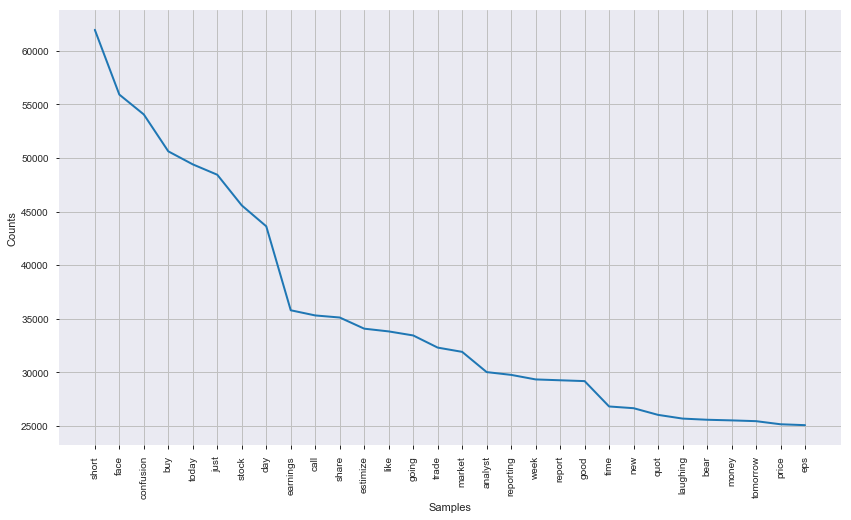

```python
plt.rcParams['figure.figsize'] = [14, 8]
fdist.plot(30,cumulative=False)
plt.show()
```

#### Finding out most common words for each sentiment score

```python
def collateScoreText(colName,score):
    text = " ".join(tweet for tweet in df_json_train[df_json_train['sentiment_score']==score]['text_clean'])
    print ("There are {} words in the combination of all review.".format(len(text)))
    return text
```

```python
def drawWordCloud(score=0,colName='text_clean'):
      token_text=word_tokenize(collateScoreText(colName,score))
      token_text = [token for token in token_text if len(token)>1]
      freqdist = FreqDist(token_text)
      wordcloud = WordCloud(background_color="White", width=3000,height=2000).generate_from_frequencies(freqdist)
      plt.imshow(wordcloud, interpolation='bilinear')
      plt.axis("off")
      plt.show()
```

### Most Common words for very negative tweets (Sentiment Score=0)

```
There are 3494860 words in the combination of all review.
```

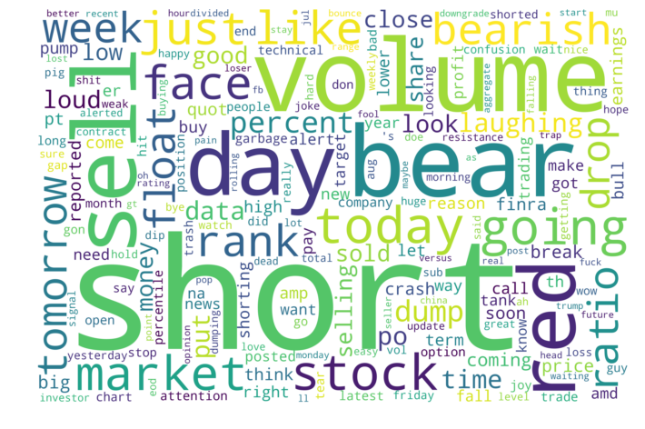

```python
drawWordCloud(score=0,colName='text_clean')
```

### Most Common words for negative tweets (Sentiment Score=1)

```
There are 5228128 words in the combination of all review.
```

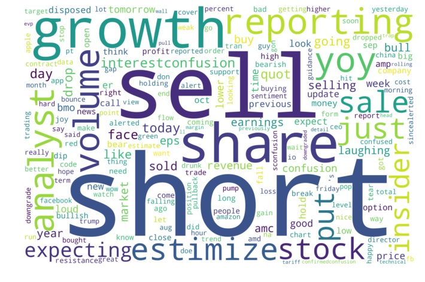

```python
drawWordCloud(score=1,colName='text_clean')
```

### Most Common words for neutral tweets (Sentiment Score=2)

```
There are 18080682 words in the combination of all review.
```

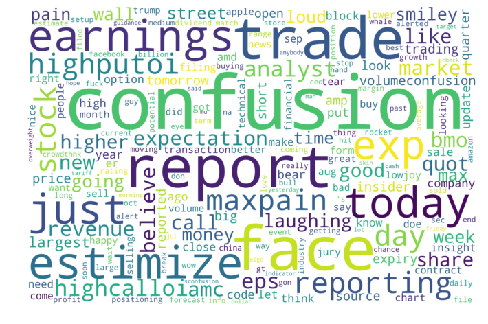

```python
drawWordCloud(score=2,colName='text_clean')
```

### Most Common words for positive tweets (Sentiment Score=3)

```
There are 8273602 words in the combination of all review.
```

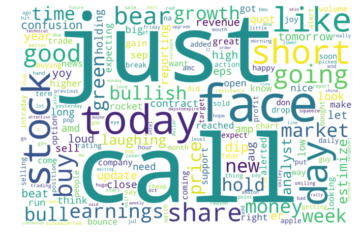

```python
drawWordCloud(score=3,colName='text_clean')
```

### Most Common words for very positive tweets (Sentiment Score=4)

```
There are 6085766 words in the combination of all review.
```

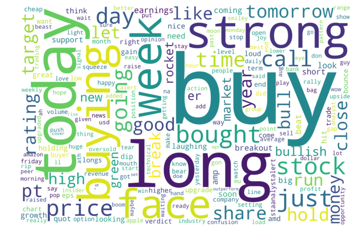

```python
drawWordCloud(score=4,colName='text_clean')
```

```python
"""
Custom Code to get top 5 companies with particular sentiment score
"""

def topTweets(score):
    company = df_json_train[df_json_train.sentiment_score==score]['ticker'].value_counts().head(5)
    company = pd.DataFrame(company)
    company = company.reset_index()
    company = company.rename(columns={"index": "Ticker", "ticker": "Count"})
    sns.barplot(x="Ticker",y='Count', data=company)
```

### Top 5 companies with most tweets with very negative tweets

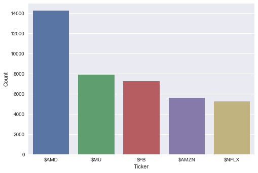

```python
topTweets(0)
```

### Top 5 companies with most tweets with negative tweets

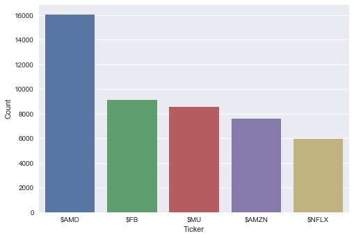

```python
topTweets(1)
```

### Top 5 companies with most tweets with neutral tweets

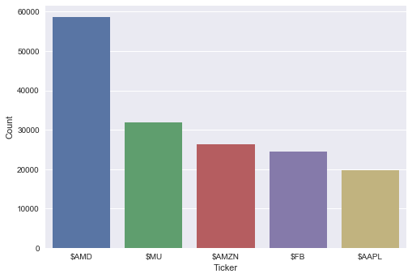

```python
topTweets(2)
```

### Top 5 companies with most tweets with positive tweets

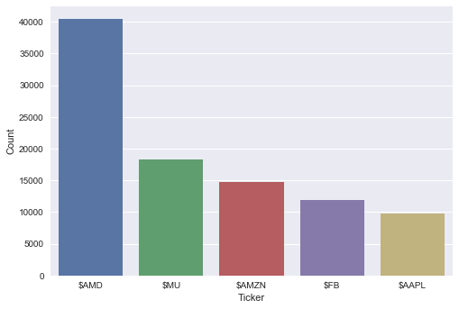

```python
topTweets(3)
```

### Top 5 companies with most tweets with very positive tweets

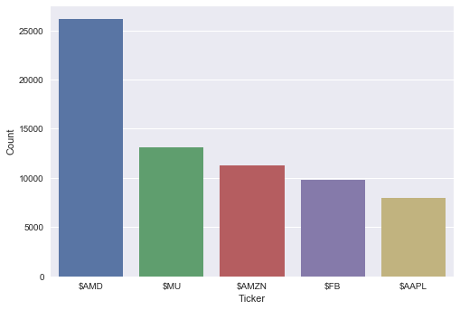

```python
topTweets(4)
```

#### Converting Timestamp to Date

```python
"""
Custom Function to change Timestamp to required
"""

def changeDateFormat(date):
    dt = datetime.strptime(str(date),'%Y-%m-%d %H:%M:%S')
    return str(datetime.strptime(str(dt.date()),'%Y-%m-%d').strftime('%d/%m/%y'))
```

```python
"""
Custom function to split string and return TimeStamp
"""

def split(text,symbol='+'):
    text = text.split(symbol)
    return text[0]
```

```python
df_json_train['date'] = df_json_train.apply(lambda row: split(row['timestamp'],'+'), axis=1)
df_json_train.head()
```

|  | sentiment_score | stocktwit_tweet | ticker | timestamp | text_clean | date |
| --- | --- | --- | --- | --- | --- | --- |
| 0 | 3 | $AMD going up but hesitating however chart is ... | $AMD | 2018-09-19 18:38:28+00:00 | going hesitating chart stable going upward | 2018-09-19 18:38:28 |
| 1 | 3 | @inforlong @MariaGascon Despite\nChina trade w... | $CAT | 2018-10-09 03:51:06+00:00 | despite china trade war held thumb | 2018-10-09 03:51:06 |
| 2 | 2 | $AVGO WTF? | $AVGO | 2018-07-12 13:35:32+00:00 | fuck | 2018-07-12 13:35:32 |
| 3 | 2 | $PH\n New Insider Filing On: \n MULLER KLAUS P... | $PH | 2018-07-19 03:32:50+00:00 | new insider filing muller klaus peter transact... | 2018-07-19 03:32:50 |
| 4 | 3 | $FB if it bounces tommorrow do the right thing... | $FB | 2018-08-23 19:07:54+00:00 | bounce tommorrow right thing fuck | 2018-08-23 19:07:54 |

```python
df_json_train['date'] = df_json_train.apply(lambda row: changeDateFormat(row['date']), axis=1)
df_json_train.head()
```

|  | sentiment_score | stocktwit_tweet | ticker | timestamp | text_clean | date |
| --- | --- | --- | --- | --- | --- | --- |
| 0 | 3 | $AMD going up but hesitating however chart is ... | $AMD | 2018-09-19 18:38:28+00:00 | going hesitating chart stable going upward | 19/09/18 |
| 1 | 3 | @inforlong @MariaGascon Despite\nChina trade w... | $CAT | 2018-10-09 03:51:06+00:00 | despite china trade war held thumb | 09/10/18 |
| 2 | 2 | $AVGO WTF? | $AVGO | 2018-07-12 13:35:32+00:00 | fuck | 12/07/18 |
| 3 | 2 | $PH\n New Insider Filing On: \n MULLER KLAUS P... | $PH | 2018-07-19 03:32:50+00:00 | new insider filing muller klaus peter transact... | 19/07/18 |
| 4 | 3 | $FB if it bounces tommorrow do the right thing... | $FB | 2018-08-23 19:07:54+00:00 | bounce tommorrow right thing fuck | 23/08/18 |

#### Copying dataframe to build model - JSON Train

```python
df_json_train_model = df_json_train.copy()
df_json_train_model.head()
```

[output not shown]

#### Dropping Unwanted Columns in JSON Train

```python
drop_cols=['stocktwit_tweet','ticker','timestamp','date']
df_json_train_model = df_json_train_model.drop(columns=drop_cols)
df_json_train_model.head()
```

|  | sentiment_score | text_clean |
| --- | --- | --- |
| 0 | 3 | going hesitating chart stable going upward |
| 1 | 3 | despite china trade war held thumb |
| 2 | 2 | fuck |
| 3 | 2 | new insider filing muller klaus peter transact... |
| 4 | 3 | bounce tommorrow right thing fuck |

#### Text Cleaning and pre-processing for JSON Test Dataframe

```python
df_json_test['text_clean'] = df_json_test['stocktwit_tweet'].str.lower()
df_json_test["text_clean"] = df_json_test["text_clean"].replace('\$\w+',' ',regex=True)
df_json_test["text_clean"] = df_json_test["text_clean"].replace('\@\w+',' ',regex=True)
df_json_test['text_clean'] = df_json_test.apply(lambda row: remove_urls(row['text_clean']), axis=1)
df_json_test['text_clean'] = df_json_test.apply(lambda row: remove_html(row['text_clean']), axis=1)
df_json_test['text_clean'] = df_json_test.apply(lambda row: convert_emoticons(row['text_clean']), axis=1)
df_json_test['text_clean'] = df_json_test.apply(lambda row: convert_emojis(row['text_clean']), axis=1)
df_json_test['text_clean'] = df_json_test.apply(lambda row: remove_punctuation(row['text_clean']), axis=1)
df_json_test['text_clean'] = df_json_test.apply(lambda row: line_strip(row['text_clean']), axis=1)
df_json_test['text_clean'] = df_json_test.apply(lambda row: removeNumbers(row['text_clean']), axis=1)
df_json_test['text_clean'] = df_json_test.apply(lambda row: apostrophe_lookup(row['text_clean']), axis=1)
df_json_test['text_clean'] = df_json_test.apply(lambda row: remove_diacritics(row['text_clean']), axis=1)
df_json_test['text_clean'] = df_json_test.apply(lambda row: chat_words_conversion(row['text_clean']), axis=1)
df_json_test['text_clean'] = df_json_test.apply(lambda row: remove_stopwords(row['text_clean']), axis=1)
df_json_test = df_json_test[df_json_test['text_clean']!='']
df_json_test['text_clean'] = df_json_test.apply(lambda row: lemmatize_words(row['text_clean']), axis=1)
df_json_test.head()
```

|  | stocktwit_tweet | ticker | timestamp | text_clean |
| --- | --- | --- | --- | --- |
| 0 | $CELG nothing to be exited about | $CELG | 2018-10-25 14:26:16+00:00 | exited |
| 1 | $AMD yall exhaust your buyer on first green ca... | $AMD | 2018-07-13 13:50:39+00:00 | yall exhaust buyer green candle byeeeeee |
| 2 | $AMD day traders day. | $AMD | 2018-09-25 19:10:54+00:00 | day trader day |
| 4 | $MU weak price action so far today. Don’t be a... | $MU | 2018-07-31 14:59:06+00:00 | weak price action far today afraid short gonna... |
| 5 | $AMZN continues to grow, specifically in key a... | $AMZN | 2018-08-04 23:54:24+00:00 | continues grow specifically key area like clou... |

#### Converting TimeStamp to Date format JSON Test

```python
df_json_test['date'] = df_json_test.apply(lambda row: split(row['timestamp'],'+'), axis=1)
df_json_test['date'] = df_json_test.apply(lambda row: changeDateFormat(row['date']), axis=1)
df_json_test.head()
```

|  | stocktwit_tweet | ticker | timestamp | text_clean | date |
| --- | --- | --- | --- | --- | --- |
| 0 | $CELG nothing to be exited about | $CELG | 2018-10-25 14:26:16+00:00 | exited | 25/10/18 |
| 1 | $AMD yall exhaust your buyer on first green ca... | $AMD | 2018-07-13 13:50:39+00:00 | yall exhaust buyer green candle byeeeeee | 13/07/18 |
| 2 | $AMD day traders day. | $AMD | 2018-09-25 19:10:54+00:00 | day trader day | 25/09/18 |
| 4 | $MU weak price action so far today. Don’t be a... | $MU | 2018-07-31 14:59:06+00:00 | weak price action far today afraid short gonna... | 31/07/18 |
| 5 | $AMZN continues to grow, specifically in key a... | $AMZN | 2018-08-04 23:54:24+00:00 | continues grow specifically key area like clou... | 04/08/18 |

#### Dropping unwanted columns JSON Test

```python
df_json_test_model = df_json_test.copy()
drop_cols=['stocktwit_tweet','ticker','timestamp','date']
df_json_test_model = df_json_test_model.drop(columns=drop_cols)
df_json_test_model.head()
```

|  | text_clean |
| --- | --- |
| 0 | exited |
| 1 | yall exhaust buyer green candle byeeeeee |
| 2 | day trader day |
| 4 | weak price action far today afraid short gonna... |
| 5 | continues grow specifically key area like clou... |

#### Splitting into Train and Validation - JSON Train

```python
trainX,valX,trainY,valY = train_test_split(df_json_train_model.loc[:,df_json_train_model.columns!="sentiment_score"],df_json_train_model.loc[:,df_json_train_model.columns=="sentiment_score"],test_size=0.2,random_state=1)
```

#### Getting the dimensions of Train and Validation Sets - JSON Train

```python
print(trainX.shape)
print(valX.shape)
print(trainY.shape)
print(valY.shape)
```

```
(802537, 1)
(200635, 1)
(802537, 1)
(200635, 1)
```

#### TF-IDF vectorization for Train Data - JSON Train

```python
tfidf_transformer = TfidfVectorizer(stop_words=ENGLISH_STOP_WORDS,lowercase=True ,norm=None)
trainX_tfidf = tfidf_transformer.fit_transform(trainX['text_clean'])
trainX_tfidf.shape
```

```
(802537, 73571)
```

#### Fitting for Validation Data - JSON Train

```python
valX_tfidf = tfidf_transformer.transform(valX['text_clean'])
valX_tfidf.shape
```

```
(200635, 73571)
```

#### Applying SMOTE due to imbalance in the target variable

```python
smote = SMOTE('minority')
```

```python
trainX_smote, trainY_smote = smote.fit_sample(trainX_tfidf,trainY.values.ravel())
valX_smote, valY_smote = smote.fit_sample(valX_tfidf,valY.values.ravel())
```

```python
print(trainX_smote.shape)
print(trainY_smote.shape)
print(valX_smote.shape)
print(valY_smote.shape)
```

```
(1084088, 73571)
(1084088,)
(270970, 73571)
(270970,)
```

#### Fitting for Test Data - JSON

```python
df_json_test_tfidf = tfidf_transformer.transform(df_json_test_model['text_clean'])
df_json_test_tfidf.shape
```

```
(255922, 73571)
```

### Model Building for Sentiment Score

```python
def selectModel(train_X,train_y, model):
    if model == 'MultinomialNB':
        return MultinomialNB().fit(train_X,train_y)
    elif model == 'ComplementNB':
        return ComplementNB().fit(train_X,train_y)
```

```python
def predictTarget(clf,train_X):
    return clf.predict(train_X)
```

```python
def printClassificationReport(train_y,pred):
    print(classification_report(train_y,pred))
```

```python
def buildModel(train_X,train_y, model):
    clf = selectModel(train_X,train_y, model)
    pred = predictTarget(clf,train_X)
    printClassificationReport(train_y,pred)
```

#### Multinomial Naive Bayes Model

```python
buildModel(trainX_smote,trainY_smote,'MultinomialNB')
```

```
              precision    recall  f1-score   support

           0       0.73      0.77      0.75    353566
           1       0.42      0.44      0.43     94751
           2       0.84      0.51      0.64    353566
           3       0.39      0.46      0.42    161381
           4       0.42      0.71      0.53    120824

    accuracy                           0.61   1084088
   macro avg       0.56      0.58      0.55   1084088
weighted avg       0.65      0.61      0.61   1084088
```

```python
buildModel(valX_smote,valY_smote,'MultinomialNB')
```

```
              precision    recall  f1-score   support

           0       0.74      0.82      0.78     88474
           1       0.47      0.46      0.47     24039
           2       0.85      0.54      0.66     88474
           3       0.43      0.49      0.46     39820
           4       0.45      0.71      0.55     30163

    accuracy                           0.64    270970
   macro avg       0.59      0.60      0.58    270970
weighted avg       0.67      0.64      0.64    270970
```

```python
clf = MultinomialNB().fit(trainX_smote,trainY_smote)
pred_multi = clf.predict(df_json_test_tfidf)
```

#### Complement Naive Bayes Model

```python
buildModel(trainX_smote,trainY_smote,'ComplementNB')
```

```
              precision    recall  f1-score   support

           0       0.68      0.85      0.76    353566
           1       0.58      0.30      0.39     94751
           2       0.76      0.60      0.67    353566
           3       0.43      0.39      0.41    161381
           4       0.46      0.65      0.54    120824

    accuracy                           0.63   1084088
   macro avg       0.58      0.56      0.55   1084088
weighted avg       0.64      0.63      0.62   1084088
```

```python
buildModel(valX_smote,valY_smote,'ComplementNB')
```

```
              precision    recall  f1-score   support

           0       0.69      0.87      0.77     88474
           1       0.60      0.32      0.42     24039
           2       0.77      0.61      0.68     88474
           3       0.47      0.40      0.43     39820
           4       0.47      0.66      0.55     30163

    accuracy                           0.65    270970
   macro avg       0.60      0.57      0.57    270970
weighted avg       0.65      0.65      0.64    270970
```

```python
clf = MultinomialNB().fit(trainX_smote,trainY_smote)
pred_Complement = clf.predict(df_json_test_tfidf)
```

```python
def plotLearningCurve(train_sizes,model,scoring,train_X,train_y):
    if model == 'MultinomialNB':
        estimator = MultinomialNB()
    elif model == 'ComplementNB':
        estimator = ComplementNB()
    elif model == 'MLP':
        estimator = MLPClassifier()
    elif model == 'DecisionTreeClassifier':
        estimator = DecisionTreeClassifier()
    elif model == 'XGBClassifier':
        estimator = XGBClassifier()

    train_sizes, train_scores, validation_scores = learning_curve(
    estimator = estimator,
    X = train_X,
    y = train_y, train_sizes = train_sizes, cv = 5,
    scoring = scoring)

    print('Training scores:\n\n', train_scores)
    print('\n', '-' * 70) # separator to make the output easy to read
    print('\nValidation scores:\n\n', validation_scores)

    train_scores_mean = train_scores.mean(axis = 1)
    validation_scores_mean = validation_scores.mean(axis = 1)

    print('Mean training scores\n\n', pd.Series(train_scores_mean, index = train_sizes))
    print('\n', '-' * 20) # separator
    print('\nMean validation scores\n\n',pd.Series(validation_scores_mean, index = train_sizes))

    plt.style.use('seaborn')
    plt.plot(train_sizes, train_scores_mean, label = 'Training Macro F1 score ')
    plt.plot(train_sizes, validation_scores_mean, label = 'Validation Macro F1 score')
    plt.ylabel('Macro F1 Score', fontsize = 14)
    plt.xlabel('Training set size', fontsize = 14)
    plt.title('Learning curves for a {} model'.format(model), fontsize = 18, y = 1.03)
    plt.legend()
    plt.ylim(0,1)
```

```python
train_sizes = [1, 5000, 10000, 216817, 650452, 867267]
```

```
Training scores:

 [[1.         1.         1.         1.         1.        ]
 [0.81820568 0.80295263 0.80295263 0.80295263 0.80295263]
 [0.7752339  0.75601241 0.75601241 0.75601241 0.75601241]
 [0.59256214 0.5772852  0.56697462 0.56697462 0.56697462]
 [0.54437509 0.53417409 0.53501835 0.53565056 0.53313265]
 [0.55903859 0.55689376 0.55688763 0.5574144  0.55718758]]

 ----------------------------------------------------------------------

Validation scores:

 [[0.0321514  0.09837304 0.09837304 0.09837304 0.09837338]
 [0.27641229 0.37116171 0.37274042 0.37179549 0.37233032]
 [0.28647504 0.40111237 0.40198432 0.40172023 0.40205497]
 [0.31047847 0.48377181 0.47658537 0.47373938 0.47540135]
 [0.48035377 0.49493714 0.4960734  0.49536136 0.49397013]
 [0.48873981 0.50052417 0.50147477 0.50185139 0.50208338]]
Mean training scores

 1         1.000000
5000      0.806003
10000     0.759857
216817    0.574154
650452    0.536470
867267    0.557484
dtype: float64

 --------------------

Mean validation scores

 1         0.085129
5000      0.352888
10000     0.378669
216817    0.443995
650452    0.492139
867267    0.498935
dtype: float64
```

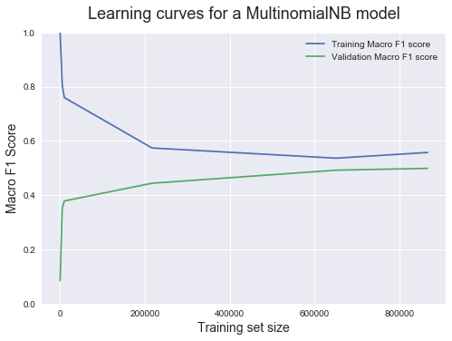

```python
plotLearningCurve(train_sizes,'MultinomialNB','f1_macro',trainX_smote,trainY_smote)
```

```
Training scores:

 [[1.         1.         1.         1.         1.        ]
 [0.81251268 0.78956256 0.78956256 0.78956256 0.78956256]
 [0.75740396 0.72785655 0.72785655 0.72785655 0.72785655]
 [0.59480151 0.57271912 0.57129142 0.57129142 0.57129142]
 [0.55157474 0.54107011 0.54028222 0.54077298 0.54137675]
 [0.55963067 0.55678341 0.55651629 0.55625671 0.55619848]]

 ----------------------------------------------------------------------

Validation scores:

 [[0.0321514  0.09837304 0.09837304 0.09837304 0.09837338]
 [0.27277974 0.38875667 0.38936411 0.38843767 0.3886927 ]
 [0.28029822 0.41319592 0.41455183 0.41271772 0.41344402]
 [0.31356894 0.4890192  0.48159699 0.47815089 0.47849412]
 [0.48429326 0.49917561 0.49961321 0.49987669 0.49856443]
 [0.49769247 0.5020176  0.50311069 0.5033011  0.50372598]]
Mean training scores

 1         1.000000
5000      0.794153
10000     0.733766
216817    0.576279
650452    0.543015
867267    0.557077
dtype: float64

 --------------------

Mean validation scores

 1         0.085129
5000      0.365606
10000     0.386842
216817    0.448166
650452    0.496305
867267    0.501970
dtype: float64
```

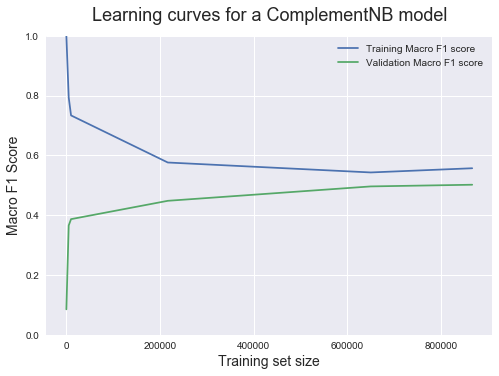

```python
plotLearningCurve(train_sizes,'ComplementNB','f1_macro',trainX_smote,trainY_smote)
```

## CSV Train Data

```python
csv_train.head()
```

|  | Id | date | ticker | SF1 | SF2 | SF3 | SF4 | SF5 | SF6 | SF7 | alpha |
| --- | --- | --- | --- | --- | --- | --- | --- | --- | --- | --- | --- |
| 0 | 1 | 21/08/18 | $NTAP | -0.628652 | 0.988891 | -0.055714 | 0.774379 | 0.551089 | -1.329229 | -0.995539 | 2 |
| 1 | 2 | 11/10/18 | $WYNN | 1.315786 | 1.438754 | 0.187327 | 0.608933 | -1.153030 | 1.859441 | 0.730995 | 3 |
| 2 | 3 | 21/08/18 | $DRI | -1.141388 | -1.455016 | 0.332755 | 0.674502 | 0.111326 | -0.478597 | -1.488157 | 1 |
| 3 | 4 | 10/07/18 | $ge | -0.054839 | -1.454149 | -0.162267 | -0.681870 | 0.307869 | -0.529987 | 0.404172 | 2 |
| 4 | 5 | 12/09/18 | $FE | -0.686366 | 0.838865 | 0.073830 | 0.679024 | 0.329463 | 1.262782 | -1.024042 | 2 |

```python
csv_train.shape
```

```
(27006, 11)
```

```python
csv_train.alpha.value_counts()
```

```
2    10912
3     5536
1     5467
4     5091
Name: alpha, dtype: int64
```

```python
csv_train['new_date'] =  pd.to_datetime(csv_train['date'], format='%d/%m/%y')
csv_train['month'] = csv_train.new_date.dt.month
```

```python
csv_train.head()
```

|  | Id | date | ticker | SF1 | SF2 | SF3 | SF4 | SF5 | SF6 | SF7 | alpha | new_date | month |
| --- | --- | --- | --- | --- | --- | --- | --- | --- | --- | --- | --- | --- | --- |
| 0 | 1 | 21/08/18 | $NTAP | -0.628652 | 0.988891 | -0.055714 | 0.774379 | 0.551089 | -1.329229 | -0.995539 | 2 | 2018-08-21 | 8 |
| 1 | 2 | 11/10/18 | $WYNN | 1.315786 | 1.438754 | 0.187327 | 0.608933 | -1.153030 | 1.859441 | 0.730995 | 3 | 2018-10-11 | 10 |
| 2 | 3 | 21/08/18 | $DRI | -1.141388 | -1.455016 | 0.332755 | 0.674502 | 0.111326 | -0.478597 | -1.488157 | 1 | 2018-08-21 | 8 |
| 3 | 4 | 10/07/18 | $ge | -0.054839 | -1.454149 | -0.162267 | -0.681870 | 0.307869 | -0.529987 | 0.404172 | 2 | 2018-07-10 | 7 |
| 4 | 5 | 12/09/18 | $FE | -0.686366 | 0.838865 | 0.073830 | 0.679024 | 0.329463 | 1.262782 | -1.024042 | 2 | 2018-09-12 | 9 |

```python
csv_train.month.value_counts()
```

```
8     7099
10    6888
7     6800
9     6219
Name: month, dtype: int64
```

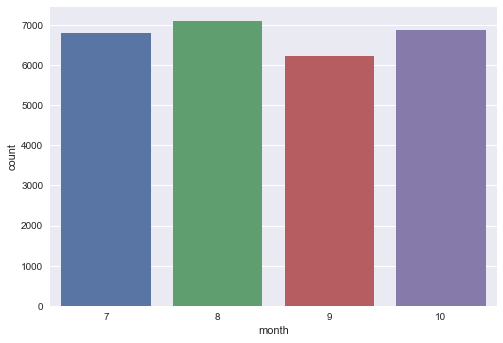

```python
sns.countplot(x="month", data=csv_train)
```

```python
def tickerInMonth(month):
    company = csv_train[csv_train.month==month]['ticker'].value_counts().head(5)
    company = pd.DataFrame(company)
    company = company.reset_index()
    company = company.rename(columns={"index": "Ticker", "ticker": "Count"})
    sns.barplot(x="Ticker",y='Count', data=company)
```

#### Number of tweets in the month of July

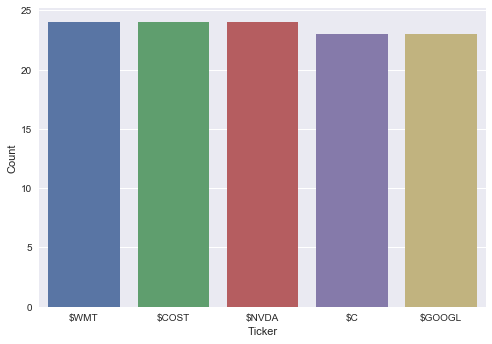

```python
tickerInMonth(7)
```

#### Number of tweets in the month of August

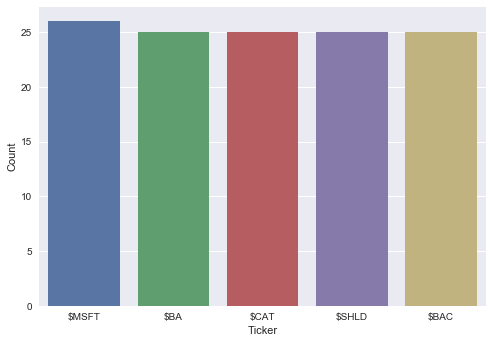

```python
tickerInMonth(8)
```

#### Number of tweets in the month of September

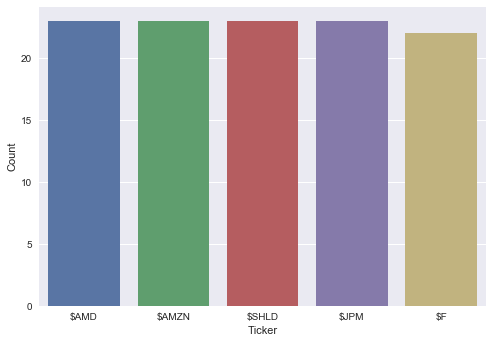

```python
tickerInMonth(9)
```

#### Number of tweets in the month of October

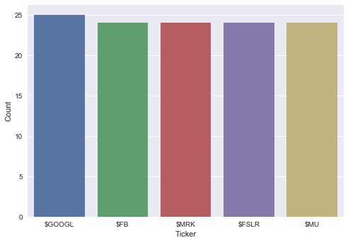

```python
tickerInMonth(10)
```

#### Converting Target Variable Alpha to Categorical

```python
csv_train['alpha'] = csv_train['alpha'].astype('category')
```

#### Copying dataframe to build model

```python
csv_train_model = csv_train.copy()
```

```python
csv_train_model.head()
```

|  | Id | date | ticker | SF1 | SF2 | SF3 | SF4 | SF5 | SF6 | SF7 | alpha | new_date | month |
| --- | --- | --- | --- | --- | --- | --- | --- | --- | --- | --- | --- | --- | --- |
| 0 | 1 | 21/08/18 | $NTAP | -0.628652 | 0.988891 | -0.055714 | 0.774379 | 0.551089 | -1.329229 | -0.995539 | 2 | 2018-08-21 | 8 |
| 1 | 2 | 11/10/18 | $WYNN | 1.315786 | 1.438754 | 0.187327 | 0.608933 | -1.153030 | 1.859441 | 0.730995 | 3 | 2018-10-11 | 10 |
| 2 | 3 | 21/08/18 | $DRI | -1.141388 | -1.455016 | 0.332755 | 0.674502 | 0.111326 | -0.478597 | -1.488157 | 1 | 2018-08-21 | 8 |
| 3 | 4 | 10/07/18 | $ge | -0.054839 | -1.454149 | -0.162267 | -0.681870 | 0.307869 | -0.529987 | 0.404172 | 2 | 2018-07-10 | 7 |
| 4 | 5 | 12/09/18 | $FE | -0.686366 | 0.838865 | 0.073830 | 0.679024 | 0.329463 | 1.262782 | -1.024042 | 2 | 2018-09-12 | 9 |

#### Dropping unwanted Columns

```python
drop_cols=['Id','date','ticker','new_date','month']
csv_train_model = csv_train_model.drop(columns=drop_cols)
```

```python
csv_train_model.head()
```

|  | SF1 | SF2 | SF3 | SF4 | SF5 | SF6 | SF7 | alpha |
| --- | --- | --- | --- | --- | --- | --- | --- | --- |
| 0 | -0.628652 | 0.988891 | -0.055714 | 0.774379 | 0.551089 | -1.329229 | -0.995539 | 2 |
| 1 | 1.315786 | 1.438754 | 0.187327 | 0.608933 | -1.153030 | 1.859441 | 0.730995 | 3 |
| 2 | -1.141388 | -1.455016 | 0.332755 | 0.674502 | 0.111326 | -0.478597 | -1.488157 | 1 |
| 3 | -0.054839 | -1.454149 | -0.162267 | -0.681870 | 0.307869 | -0.529987 | 0.404172 | 2 |
| 4 | -0.686366 | 0.838865 | 0.073830 | 0.679024 | 0.329463 | 1.262782 | -1.024042 | 2 |

#### Splitting into train and validation sets

```python
trainX,valX,trainY,valY = train_test_split(csv_train_model.loc[:,csv_train_model.columns!="alpha"],csv_train_model.loc[:,csv_train_model.columns=="alpha"],test_size=0.2,random_state=1)
```

```python
print(trainX.shape)
print(valX.shape)
print(trainY.shape)
print(valY.shape)
```

```
(21604, 7)
(5402, 7)
(21604, 1)
(5402, 1)
```

```python
csv_trainX_smote, csv_trainY_smote = smote.fit_sample(trainX,trainY.values.ravel())
csv_valX_smote, csv_valY_smote = smote.fit_sample(valX,valY.values.ravel())
```

```python
print(csv_trainX_smote.shape)
print(csv_trainY_smote.shape)
print(csv_valX_smote.shape)
print(csv_valY_smote.shape)
```

```
(26353, 7)
(26353,)
(6474, 7)
(6474,)
```

### Model Building

#### Finding Best Params using Random Search

```python
dt=tree.DecisionTreeClassifier()
DT_param_grid_1={
    'criterion':['gini','entropy'],
    'max_depth':np.arange(4,20,1),
    'min_samples_split':np.arange(0.001,0.1,0.01),
    'max_features':['log2','sqrt','auto'],
    'min_weight_fraction_leaf':np.arange(0.001,0.25,0.05)
}
r_search=RandomizedSearchCV(dt,param_distributions=DT_param_grid_1,n_iter=1500,verbose=1,cv=5,n_jobs=-1)
r_search.fit(csv_trainX_smote,csv_trainY_smote)
r_search.best_params_
```

```
Fitting 5 folds for each of 1500 candidates, totalling 7500 fits
```

```
[Parallel(n_jobs=-1)]: Using backend LokyBackend with 8 concurrent workers.
[Parallel(n_jobs=-1)]: Done  34 tasks      | elapsed:    7.5s
[Parallel(n_jobs=-1)]: Done 521 tasks      | elapsed:   11.2s
[Parallel(n_jobs=-1)]: Done 1521 tasks      | elapsed:   18.7s
[Parallel(n_jobs=-1)]: Done 2921 tasks      | elapsed:   32.2s
[Parallel(n_jobs=-1)]: Done 4721 tasks      | elapsed:   48.3s
[Parallel(n_jobs=-1)]: Done 6921 tasks      | elapsed:  1.1min
[Parallel(n_jobs=-1)]: Done 7485 out of 7500 | elapsed:  1.2min remaining:    0.0s
[Parallel(n_jobs=-1)]: Done 7500 out of 7500 | elapsed:  1.2min finished
```

```
{'min_weight_fraction_leaf': 0.001,
 'min_samples_split': 0.001,
 'max_features': 'auto',
 'max_depth': 19,
 'criterion': 'entropy'}
```